# Analizando el Estudio Longitudinal Social de Chile (ELSOC)

ELSOC Est. Descriptiva Graficos

Trabajaremos con algunas variables de las tres olas del Estudio Longitudinal Social de Chile (ELSOC) del Centro de Estudios de Conflicto y Cohesión Social (COES).

Francisco Guzmán  
04-23-2021

# Librerías

```r
library(haven)
library(dplyr)
library(ggplot2)
library(summarytools)
library(table1)
```

# Base de Datos

Debemos utilizar la base creada en el post [rbind.fill para armado de bases](https://panchog.netlify.app/posts/2021-04-15-elsoc/).

```r
base <- readRDS("elsoc.rds")
```

## Buscador

Con este comando podemos buscar palabras claves en las etiquetas de las variables.

```r
labelled::look_for(base, "ingreso", "salario", details = "none") %>%
  dplyr::as_tibble()
```

```
# A tibble: 11 x 3
     pos variable label
   <int> <chr>    <chr>
 1   161 c18_11   Grado de acuerdo: Las diferencias de ingreso son de~
 2   203 d03_01   Salario percibido: Gerente gran empresa
 3   204 d03_02   Salario percibido: Obrero no calificado
 4   205 d04_01   Salario justo: Gerente gran empresa
 5   206 d04_02   Salario justo: Obrero no calificado
 6   293 m13      Ingreso mensual entrevistado (monto)
 7   294 m14      Ingreso mensual del entrevistado (en tramos)
 8   296 m16      Satisfaccion con ingreso
 9   310 m29      Ingreso total del hogar (monto)
10   311 m30      Ingreso total del hogar (en tramos)
11   581 c37_05   Grado de acuerdo: Restricciones ingreso migrantes
```

## Nuevo DataFrame

Creamos un nuevo *DataFrame* con las variables que utilizaremos.

```r
elsoc <- base %>%
  select(idencuesta, ola,
         d03_01, d03_02, d04_01, d04_02,
         c18_11
         )
```

## dfSummary

Una buena forma de tener una visión general de las variables a utilizar, es corriendo el siguiente comando (aparecerá en *viewer* y podremos abrir una nueva ventana para visualizar mejor):

```r
view(dfSummary(elsoc))
```

La variable $c18\_11$ es categórica, por lo que nos podría interesar el siguiente comando:

```r
sjmisc::frq(elsoc$c18_11) # se antepone sjmisc:: porque el comando es de esa librería
```

```
Grado de acuerdo: Las diferencias de ingreso son demasiado grandes (x) <numeric>
# total N=9148  valid N=9148  mean=-0.82  sd=68.32

Value |                          Label |    N | Raw % | Valid % | Cum. %
------------------------------------------------------------------------
 -999 |          No Responde (no leer) |   11 |  0.12 |    0.12 |   0.12
 -888 |              No Sabe (no leer) |   40 |  0.44 |    0.44 |   0.56
    1 |       Totalmente en desacuerdo |  188 |  2.06 |    2.06 |   2.61
    2 |                  En desacuerdo |  443 |  4.84 |    4.84 |   7.46
    3 | Ni de acuerdo ni en desacuerdo |  413 |  4.51 |    4.51 |  11.97
    4 |                     De acuerdo | 3565 | 38.97 |   38.97 |  50.94
    5 |          Totalmente de acuerdo | 4488 | 49.06 |   49.06 | 100.00
 <NA> |                           <NA> |    0 |  0.00 |    <NA> |   <NA>
```

## Missing Values

Dado que en la ELSOC se asigna a los *missing values* un código único de -999 a “No Responde” y -888 “No Sabe”, hacemos la siguiente modificación para dejar estos números como *NA*.

```r
elsoc[elsoc == -999] <- NA
elsoc[elsoc == -888] <- NA
```

Podemos volver a correr **view(dfSummary(elsoc))** y notaremos las diferencias.

## Creación de variables

Se crean nuevas variables para que las anteriores queden expresadas en millones de pesos y se crean algunos ratios (con y sin logaritmo natural).

```r
attach(elsoc)

#salario percibido en $ millones
elsoc$sp_gerente <- d03_01/1000000
elsoc$sp_obrero <- d03_02/1000000

#salario justo en $ millones
elsoc$sj_gerente <- d04_01/1000000
elsoc$sj_obrero <- d04_02/1000000

#brecha percibida
elsoc$bp <-  elsoc$sp_gerente/elsoc$sp_obrero
elsoc$bp_ln <-  log(elsoc$sp_gerente/elsoc$sp_obrero)

#brecha justa
elsoc$bj <-  elsoc$sj_gerente/elsoc$sj_obrero
elsoc$bj_ln <-  log(elsoc$sj_gerente/elsoc$sj_obrero)
```

# Outliers

## Revisión

Creamos un *DataFrame* auxiliar para hacer el análisis.

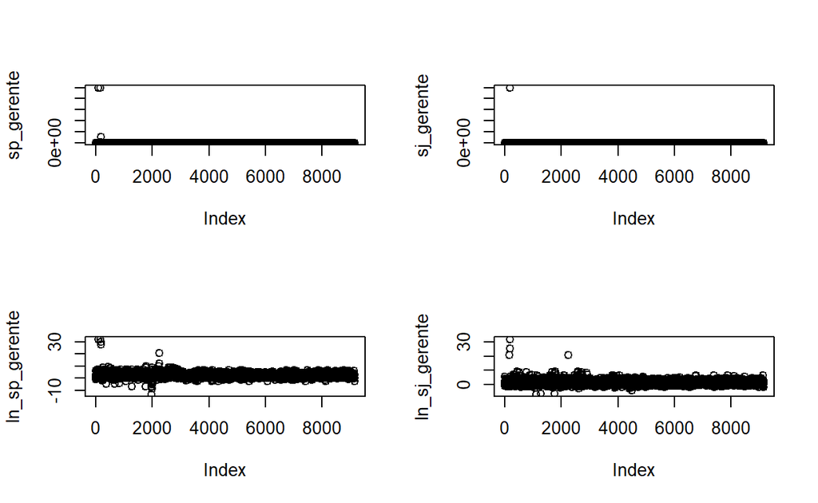

```r
aux_outliers <- elsoc %>%
  select(idencuesta, ola, sp_gerente,sp_obrero,sj_gerente,sj_obrero)

aux_outliers$ln_sp_gerente <- log(elsoc$sp_gerente)
aux_outliers$ln_sj_gerente <- log(elsoc$sj_gerente)

attach(aux_outliers)
par(mfrow=c(2,2))
plot(sp_gerente)
plot(sj_gerente)
plot(ln_sp_gerente)
plot(ln_sj_gerente)
```

```r
elsoc[!(elsoc$idencuesta %in% c("3101041","3301091", "3301183", "3301113", "13115035","13115022")
       & elsoc$ola == 1),
       ]
```

# Estadística Descriptiva

## table1

Utilizaremos el comando **table1** para crear una tabla con información de las principales estadísticas de las variables elegidas.

```r
label(elsoc$sp_gerente)   <- "Salario percibido: Gerente gran empresa ($MM)"
label(elsoc$sp_obrero)   <- "Salario Percibido: Obrero no calificado ($MM)"
label(elsoc$sj_gerente)   <- "Salario justo: Gerente gran empresa ($MM)"
label(elsoc$sj_obrero)   <- "Salario justo: Obrero no calificado ($MM)"
label(elsoc$bp)   <- "Brecha Percibida"
label(elsoc$bj)   <- "Brecha Justa"

table1(~ sp_gerente + sp_obrero + sj_gerente +  sj_obrero + bp + bj | ola,
       data = elsoc,
       overall = F,
       render.continuous=c("Media (Desv. est.)"="Mean (SD)",
                           "Mediana [Rango]"="Median [Min, Max]",
                           "Obs."="N"),
       render.missing = NULL,
       topclass="Rtable1-zebra",
       footnote = "Fuente: Elaboración propia en base a datos del Estudio Longitudinal Social de Chile (ELSOC)",
       caption = "Salario Percibido, Salario Justo y Brechas"
       )
```

Salario Percibido, Salario Justo y Brechas

|  | 1 (N=2927) | 2 (N=2473) | 3 (N=3748) |
| --- | --- | --- | --- |
| Salario percibido: Gerente gran empresa ($MM) |  |  |  |
| Media (Desv. est.) | 75000000000 (2670000000000) | 21.3 (59.5) | 18.0 (47.1) |
| Mediana [Rango] | 11.0 [0, 100000000000000] | 8.00 [0, 900] | 8.00 [0.100, 900] |
| Obs. | 2813 | 2213 | 3518 |
| Salario Percibido: Obrero no calificado ($MM) |  |  |  |
| Media (Desv. est.) | 34500000000 (1860000000000) | 0.312 (0.204) | 0.400 (4.63) |
| Mediana [Rango] | 0.250 [0, 100000000000000] | 0.270 [0, 5.00] | 0.288 [0.0500, 280] |
| Obs. | 2897 | 2359 | 3660 |
| Salario justo: Gerente gran empresa ($MM) |  |  |  |
| Media (Desv. est.) | 35800000000 (1890000000000) | 8.76 (36.7) | 6.74 (20.5) |
| Mediana [Rango] | 5.00 [0, 100000000000000] | 3.00 [0, 600] | 3.00 [0.100, 500] |
| Obs. | 2796 | 2207 | 3513 |
| Salario justo: Obrero no calificado ($MM) |  |  |  |
| Media (Desv. est.) | 346000000000 (18600000000000) | 2.48 (24.4) | 0.602 (0.529) |
| Mediana [Rango] | 0.500 [0, 1000000000000000] | 0.500 [0, 480] | 0.500 [0.100, 20.0] |
| Obs. | 2894 | 2353 | 3677 |
| Brecha Percibida |  |  |  |
| Media (Desv. est.) | 335000000000 (12100000000000) | 84.3 (470) | 62.1 (174) |
| Mediana [Rango] | 41.7 [0, 500000000000000] | 28.0 [0.300, 20000] | 26.7 [0.107, 3480] |
| Obs. | 2806 | 2212 | 3506 |
| Brecha Justa |  |  |  |
| Media (Desv. est.) | 59800000000 (3160000000000) | 17.2 (85.5) | 12.8 (40.1) |
| Mediana [Rango] | 8.57 [0, 167000000000000] | 6.00 [0, 2000] | 6.00 [0.0140, 1250] |
| Obs. | 2787 | 2202 | 3507 |

Fuente: Elaboración propia en base a datos del Estudio Longitudinal Social de Chile (ELSOC)

# Código

```r
knitr::opts_chunk$set(echo = TRUE)
library(haven)
library(dplyr)
library(ggplot2)
library(summarytools)
library(table1)

base <- readRDS("elsoc.rds")

labelled::look_for(base, "ingreso", "salario", details = "none") %>%
  dplyr::as_tibble()

elsoc <- base %>%
  select(idencuesta, ola,
         d03_01, d03_02, d04_01, d04_02,
         c18_11
         )

view(dfSummary(elsoc))

sjmisc::frq(elsoc$c18_11) # se antepone sjmisc:: porque el comando es de esa librería

elsoc[elsoc == -999] <- NA
elsoc[elsoc == -888] <- NA

attach(elsoc)

#salario percibido en $ millones
elsoc$sp_gerente <- d03_01/1000000
elsoc$sp_obrero <- d03_02/1000000

#salario justo en $ millones
elsoc$sj_gerente <- d04_01/1000000
elsoc$sj_obrero <- d04_02/1000000

#brecha percibida
elsoc$bp <-  elsoc$sp_gerente/elsoc$sp_obrero
elsoc$bp_ln <-  log(elsoc$sp_gerente/elsoc$sp_obrero)

#brecha justa
elsoc$bj <-  elsoc$sj_gerente/elsoc$sj_obrero
elsoc$bj_ln <-  log(elsoc$sj_gerente/elsoc$sj_obrero)

aux_outliers <- elsoc %>%
  select(idencuesta, ola, sp_gerente,sp_obrero,sj_gerente,sj_obrero)

aux_outliers$ln_sp_gerente <- log(elsoc$sp_gerente)
aux_outliers$ln_sj_gerente <- log(elsoc$sj_gerente)

attach(aux_outliers)
par(mfrow=c(2,2))
plot(sp_gerente)
plot(sj_gerente)
plot(ln_sp_gerente)
plot(ln_sj_gerente)

elsoc[!(elsoc$idencuesta %in% c("3101041","3301091", "3301183", "3301113", "13115035","13115022")
       & elsoc$ola == 1),
       ]


label(elsoc$sp_gerente)   <- "Salario percibido: Gerente gran empresa ($MM)"
label(elsoc$sp_obrero)   <- "Salario Percibido: Obrero no calificado ($MM)"
label(elsoc$sj_gerente)   <- "Salario justo: Gerente gran empresa ($MM)"
label(elsoc$sj_obrero)   <- "Salario justo: Obrero no calificado ($MM)"
label(elsoc$bp)   <- "Brecha Percibida"
label(elsoc$bj)   <- "Brecha Justa"

table1(~ sp_gerente + sp_obrero + sj_gerente +  sj_obrero + bp + bj | ola,
       data = elsoc,
       overall = F,
       render.continuous=c("Media (Desv. est.)"="Mean (SD)",
                           "Mediana [Rango]"="Median [Min, Max]",
                           "Obs."="N"),
       render.missing = NULL,
       topclass="Rtable1-zebra",
       footnote = "Fuente: Elaboración propia en base a datos del Estudio Longitudinal Social de Chile (ELSOC)",
       caption = "Salario Percibido, Salario Justo y Brechas"
       )
```

# Referencias

- [Percepción de Desigualdad Económica en Chile: Medición, Diferencias y Determinantes](http://ojs.uc.cl/index.php/psykhe/article/view/20717)
- [dataverse.harvard.edu](https://dataverse.harvard.edu/dataverse/coes_data_repository?q=&types=datasets&fq0=subtreePaths%3A%22%2F3130692%22&fq1=dvObjectType%3A%28datasets+OR+files%29&sort=dateSort&order=desc&page=1)
- [Descriptive statistics in R](https://statsandr.com/blog/descriptive-statistics-in-r/)
- [Introduction to summarytools](https://cran.r-project.org/web/packages/summarytools/vignettes/Introduction.html)
- [table1 Package](https://cran.r-project.org/web/packages/table1/vignettes/table1-examples.html)